# White Wine Explorative Data Analysis

### Total sulfur dioxide / Quality

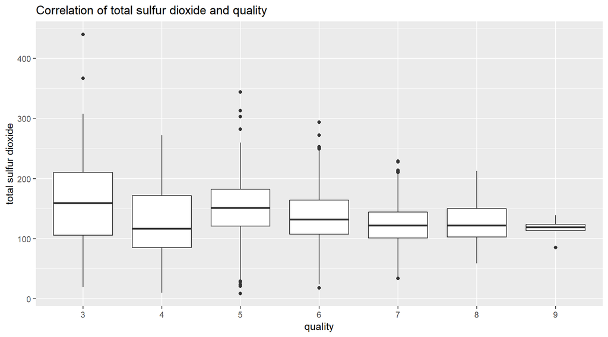

This is almost the same picture like we saw for free sulfur dioxides. This is quite reasonabe, as free sulfur dioxide is a subset of total sulfur dioxide.

### Density / Quality

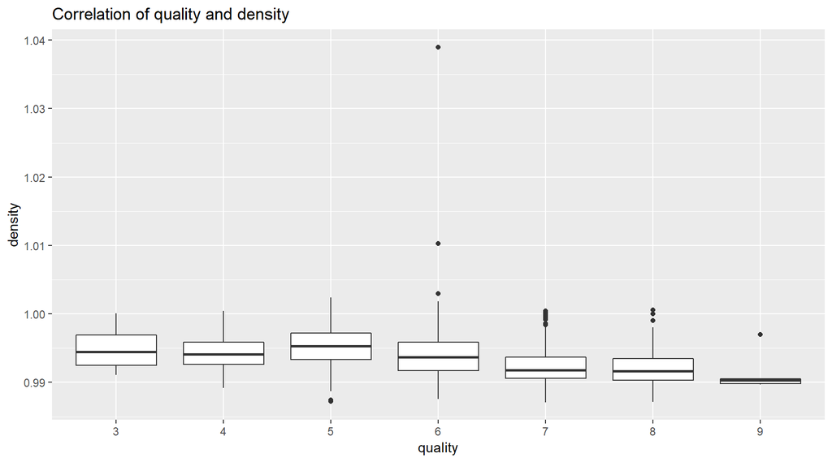

As stated before, the density decreases if a whine contains more alcohol. We already know that the quality increases with an increasing alcohol level, so this plot shows us that density and alcohol and therefore quality do have negative correlation. Let’s plot that into a point graph.

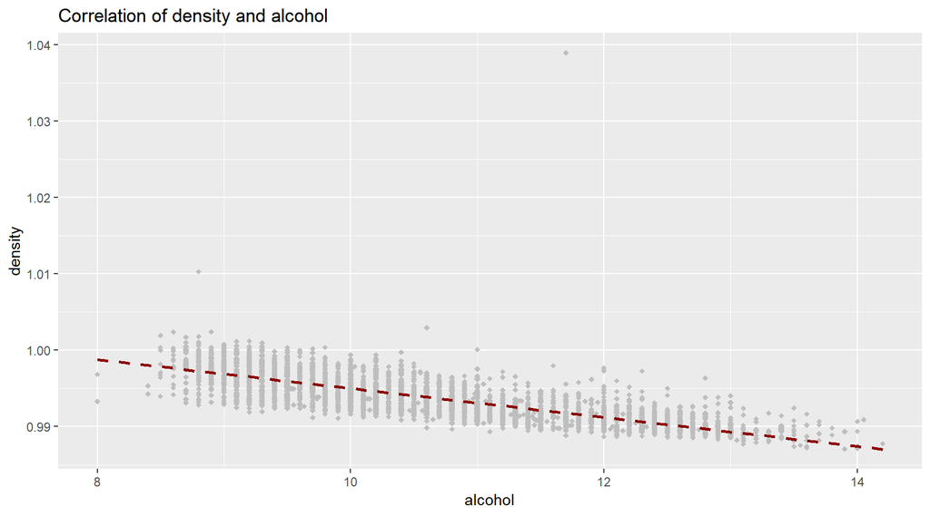

```
##
## Call:
## lm(formula = as.numeric(quality) ~ density, data = white_wine)
##
## Residuals:
##     Min      1Q  Median      3Q     Max
## -3.1441 -0.6258  0.0005  0.5162  4.2102
##
## Coefficients:
##             Estimate Std. Error t value Pr(>|t|)
## (Intercept)   94.277      4.003   23.55   <2e-16 ***
## density      -90.942      4.027  -22.58   <2e-16 ***
## ---
## Signif. codes:  0 '***' 0.001 '**' 0.01 '*' 0.05 '.' 0.1 ' ' 1
##
## Residual standard error: 0.8429 on 4896 degrees of freedom
## Multiple R-squared:  0.09432,    Adjusted R-squared:  0.09414
## F-statistic: 509.9 on 1 and 4896 DF,  p-value: < 2.2e-16
```

According to our lineal model and the r-squared value, the density explains about 9% of the variablity in the quality of white wines.

### pH / Quality

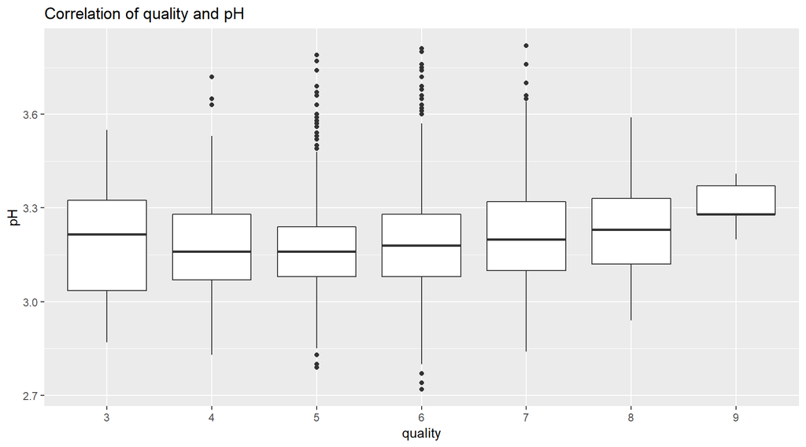

The quality seems to increase with a higher value of pH. We do have quite some outliers for average rated wines.

As there are some variables which are influencing the pH, we are going to take a look on how they are influencing this valuable. We are using scatter plots for this.

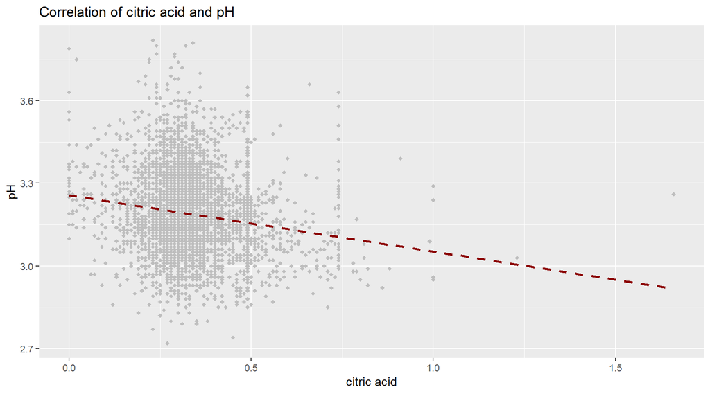

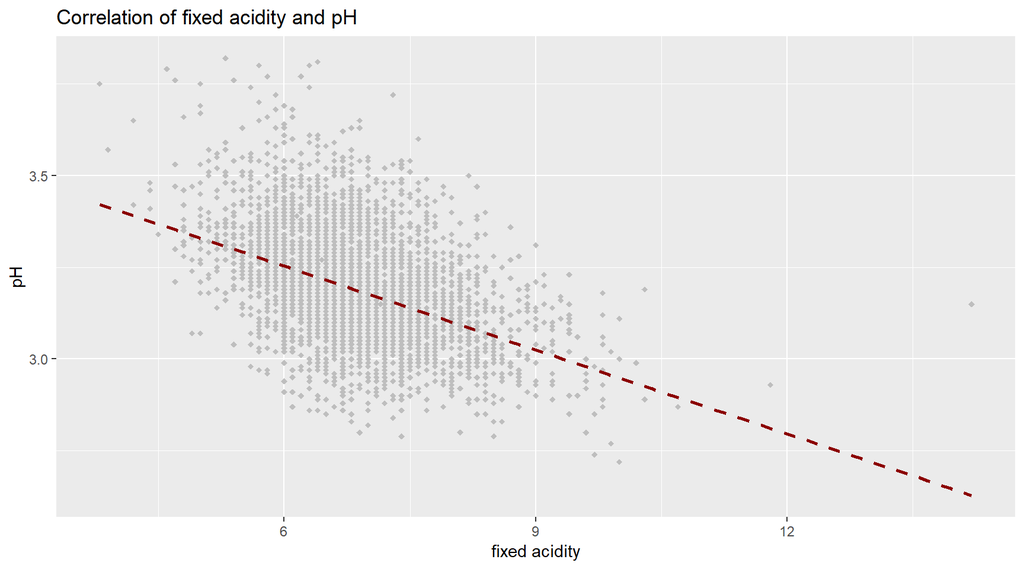

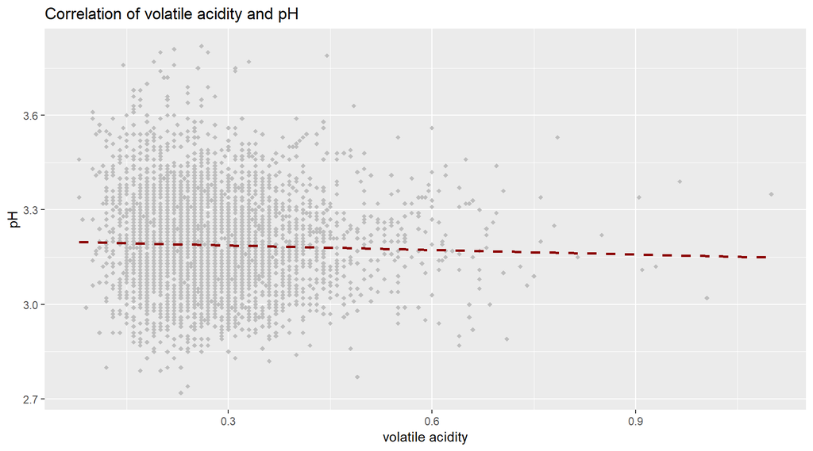

These three graphs show what i would suspect: Acidity seems to have a negative correlation with pH. The higher the accidty, the lower the pH value.

### Sulphates / Quality

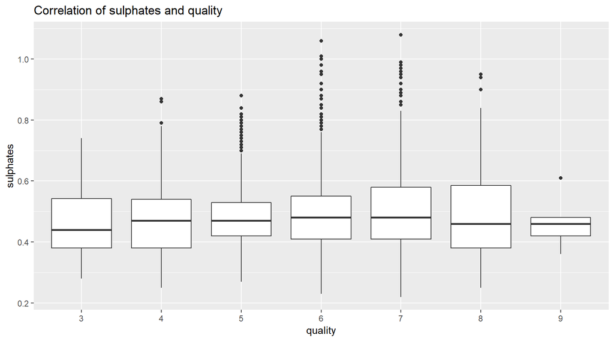

Sulphates seem to have a slight positive correlation on the quality of wines. Thought the best wines don’t seem to be highest on sulphates, the good rated wines seem to have a higher concentration of sulphates than average or bad wines.

# Bivariate Analysis

### Talk about some of the relationships you observed in this part of theinvestigation. How did the feature(s) of interest vary with other features inthe dataset?

1. Alcohol seems to have to highest positive correlation with quality. As residual sugar correlates negatively with alcohol, residual sugar correlates a lot with quality as well, even though the correlation coefficent for quality and residual sugar is very low. This shows us, that even though we might have no correlation at first, it doesn’t mean we have non. Properties might have an direct influence on quality.
2. We can see that acidity seems to have a negative correlation with pH. Again, we do have indirect correlations with quality. As pH has a positive correlation with quality and pH has negative correlations with acidities, it tells us that the more acid whines are, the quality will decrease.
3. Sulphates seem to have a positive correlation on quality, but it is only week and doesn’t “guarantee the best quality.
4. Chlorides have only a weak correlation with quality, but we can see that better wines seem to have a slightly lower values of chlorides.
5. Alcohol explains about 19 % of the variance, while the density explains about 9%. Because of that, we will have to do some further analysis to get more insights and that is why we have to do a multivariate analysis.

### Did you observe any interesting relationships between the other features (not the main feature(s) of interest)?

Yes, i did. I already described it above, so i will only list it here. I discovered a strong relationship between: - alcohol and sugar - alcohol and density - pH and the acidities - free sulfur dioxides and total sulfur dioxides

### What was the strongest relationship you found?

The strongest relationship i found while calculating and plotting is the relationshop between quality and alcohol. There are other relationships which might be stronger, such as density and residual sugar or density and alcohol, but in terms of the strongest relationship with quality, alcohol is the stronest i found.

# Multivariate Plots Section

### Alcohol, residual sugar and quality

First, let’s take a look at some of the strongest relationships we descovered, which are alcohol and quality and alcohol and sugar.

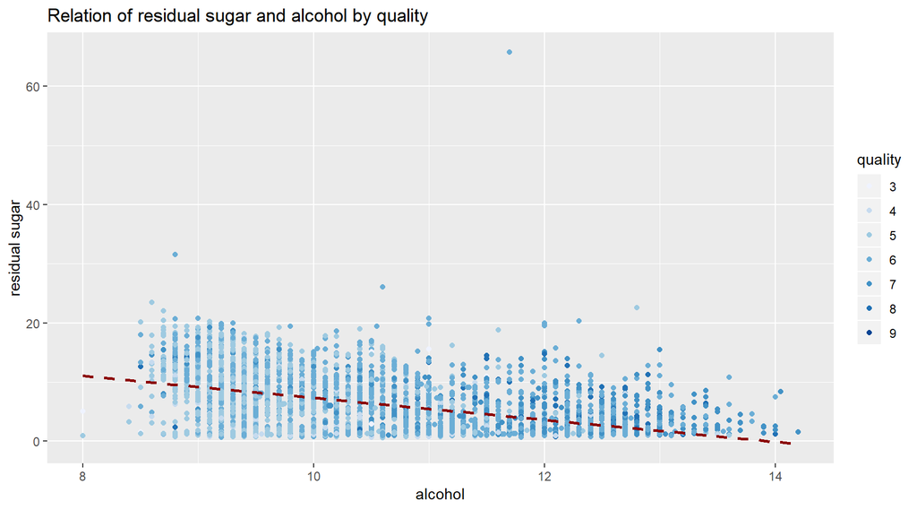

We can see that there is a negative correlation. Let’s plot residual sugar and alcohl with rating.

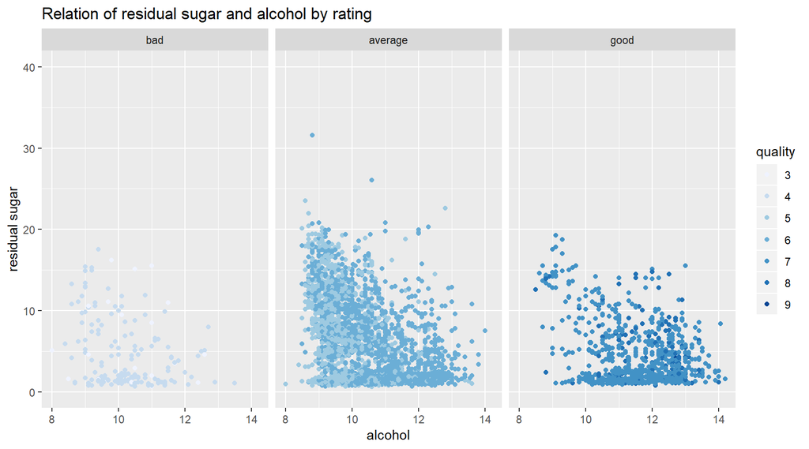

This confirms what we already saw in our bivariate analysis. Wines which are reated as “good” tend to have more alcohol and less residual sugar.

#### Alcohol, density and quality

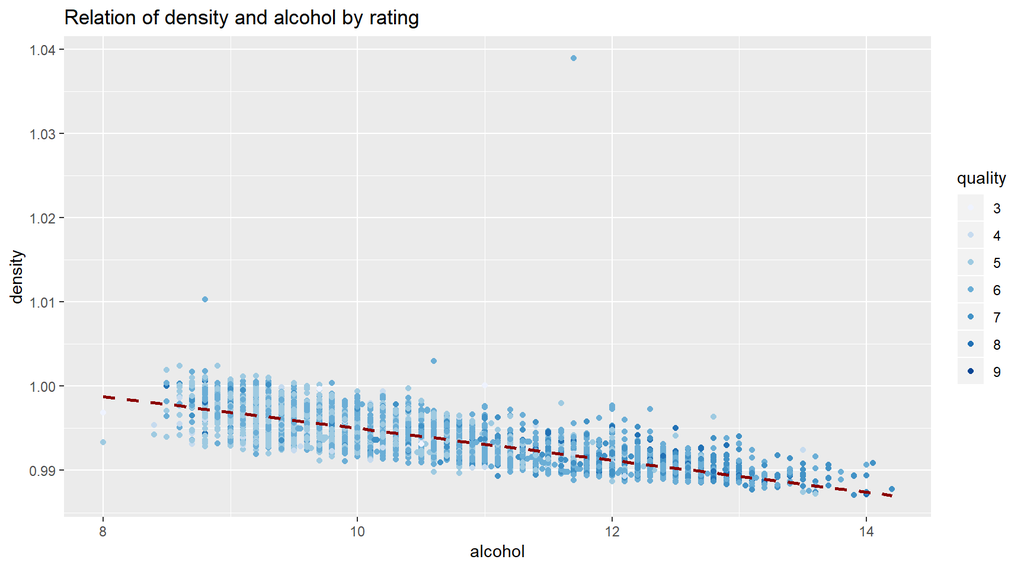

Negative correlation here as well. Again, plot it with rating:

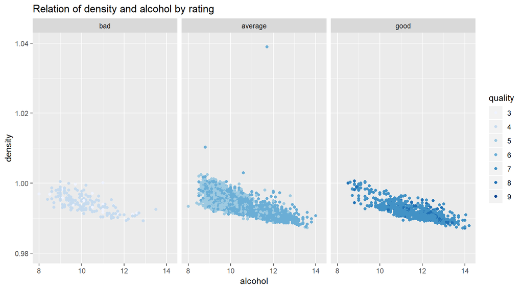

### Alcohol, sulphates and quality

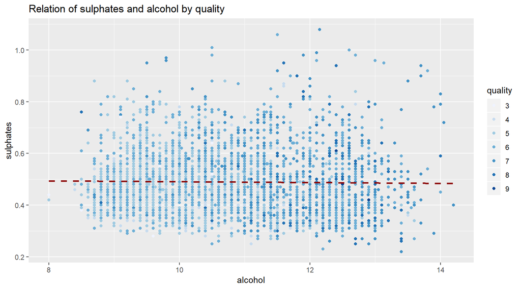

Ok, this shows us that the correlation is quite small. Let’s plot it again, this time with rating in place of quality.

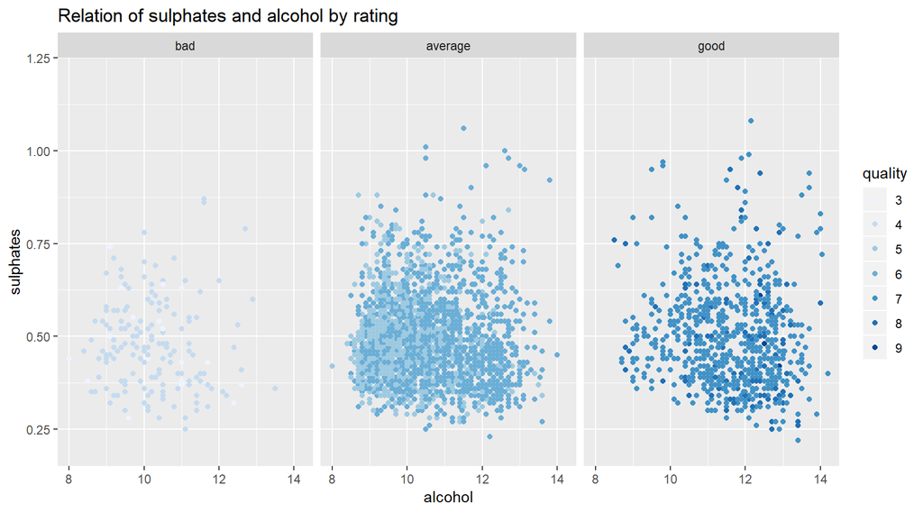

By plotting the correlation between alcohol and sulphates with our rating, we can see that the there really is no evidence that sulphates are a property which make up for a good wine. The distribution isn’t really different from those who are rated “average”, so i think there are still other properties which are important for a good (or accountable for a bad) wine.

### pH, acidity and quality

We already know that acidity has a negative correlation with pH and that pH has a (weak) positive correlation with quality. Let’s see if we can get a clearer picture of the correation of these properties along with the quality.

[figure not shown]

We have a negative correlation here. Let’s see how the picture is for rating.

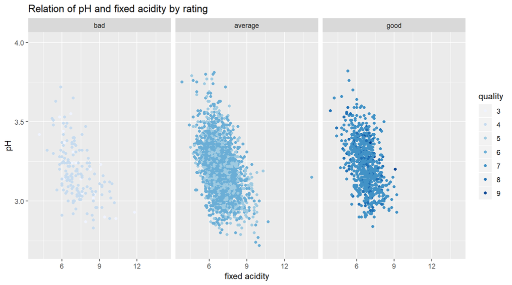

Good rated wines seem to have a slightly higher pH value compared to average and bad wines and they tend to have a lower value of fixed acidity. That is reasonable, as it confirms the negative correlation we saw before.

### Volatile acidity, pH and quality

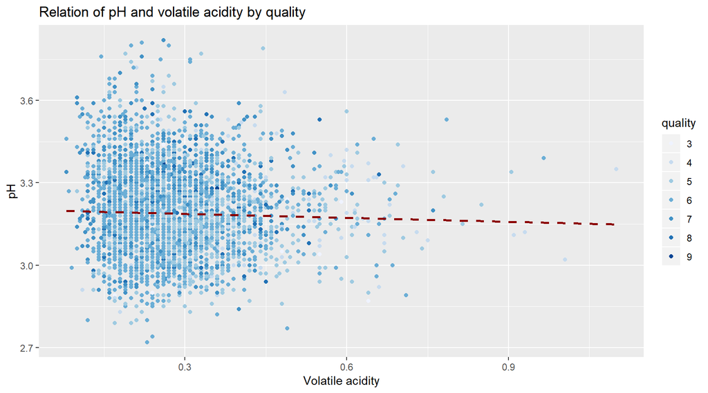

We already know that the volatile acidity has a weak negative correlation with pH. The plot above shows us, that with better quality, the wines tend to have less volatile acidity, thus getting a higher pH value. This picture get’s a bit clearer if we plot these values with rating.

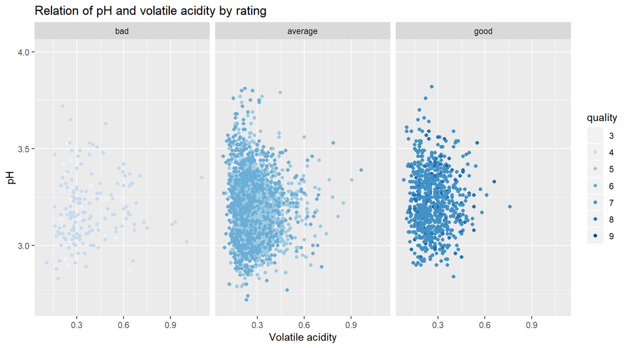

Sure, the effect is quite small, but a higher pH seems to coreelate with a better quality.

### Citric acid, pH and quality

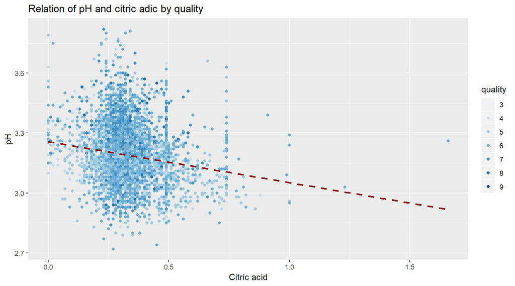

Taking a look at this plot, we can see a negative correlation between pH and citric acid, which makes sense. Let’s take a look at the rating.

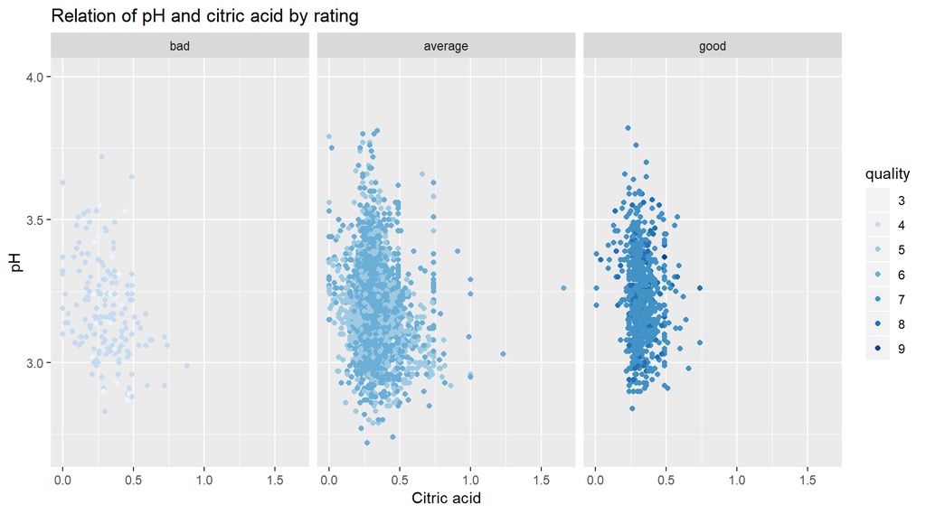

Plotting helps us to get a better view right here. We can now see that good rated wines seem to come with a lower citric acid value and a higher pH one.

Now that we now the possible influence of acidities on quality, let’s have a look at the correlation of alcohol and pH in terms of quality.

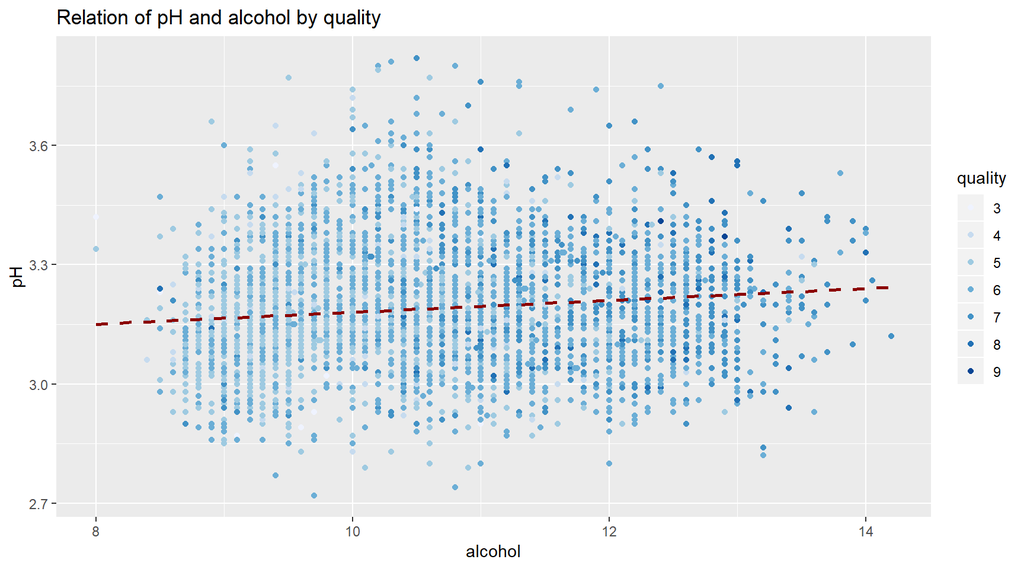

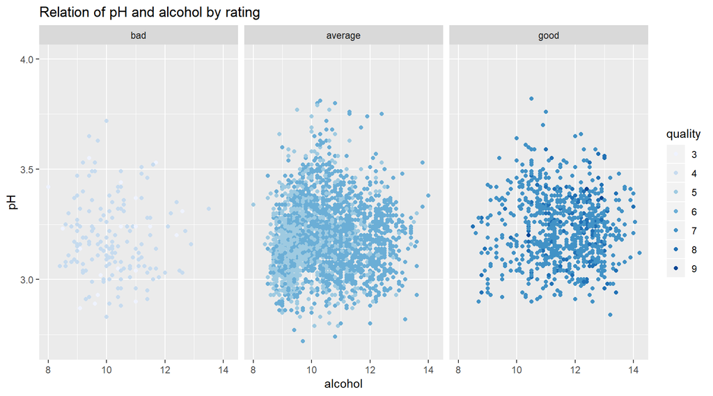

Good wines seem to have a high alcohol concentration and a higher pH value.

### Citric acid, volatile acidity and quality

Let’s have a closer look at the relationship between the different acidities and their distribution regarding quality.

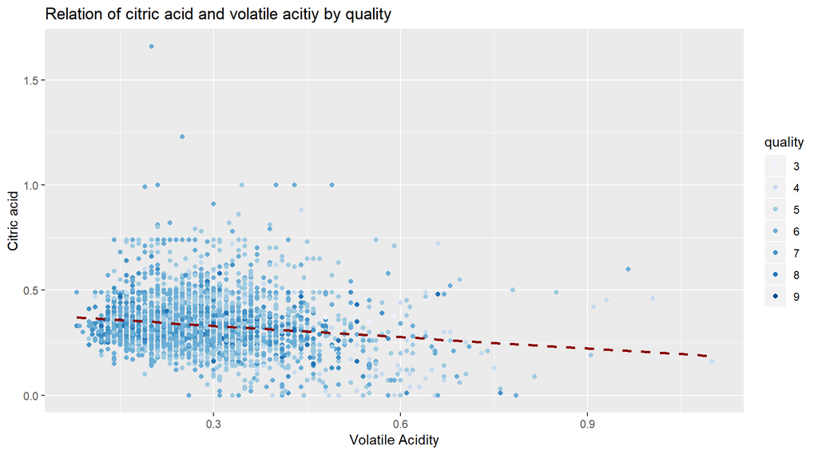

This picture let’s me think that wines with a high quality rating seem to have a lower volatile acidity vaue and a comparably low citric acid value. Let’s plot it with the rating value.

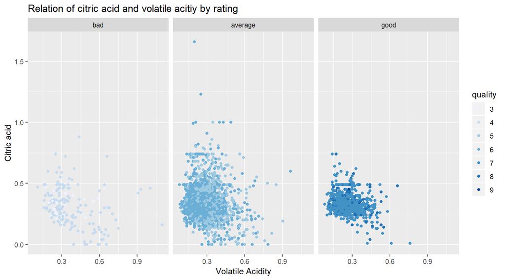

Yes. As i already assumed, good rated wines come with a lower value of citric acid and volatile acidity. Let’s see how this behaves with a value which is closely relted to volatile acidity, which is fixed acidity.

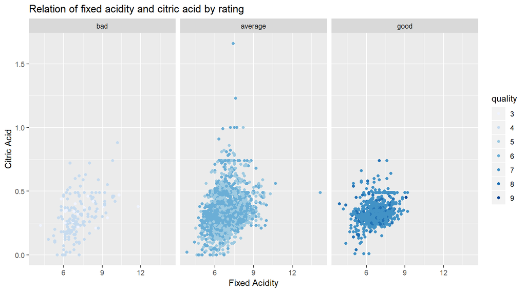

This is even more obvious: Good wines seem to have lower citric acid and fixed acidity as well.

### Volatile acidity, fixed acidity and quality

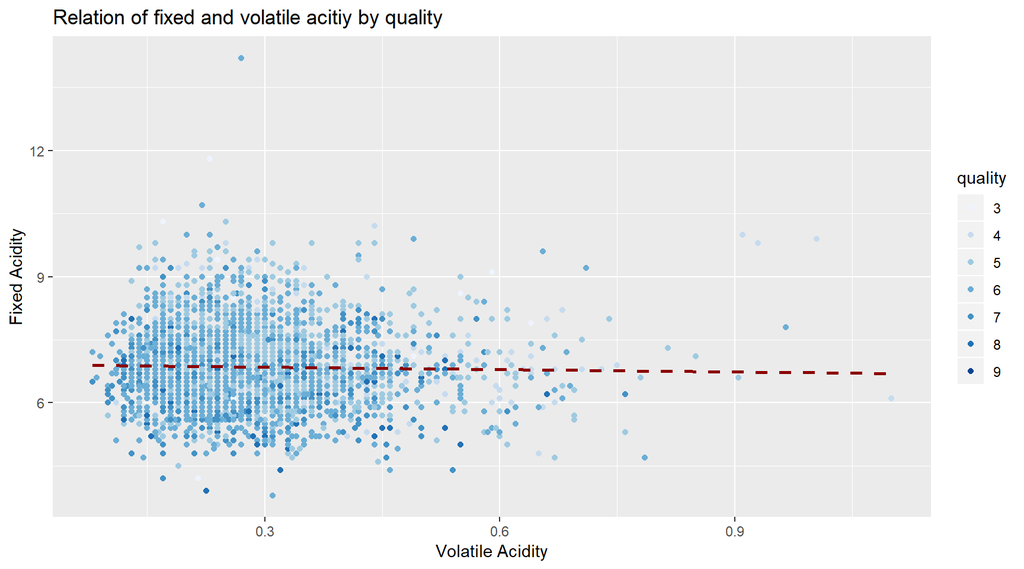

There is close to no correlation between fixed acidity and volatile acidity in terms of quality. If there is, it is slightly negative.

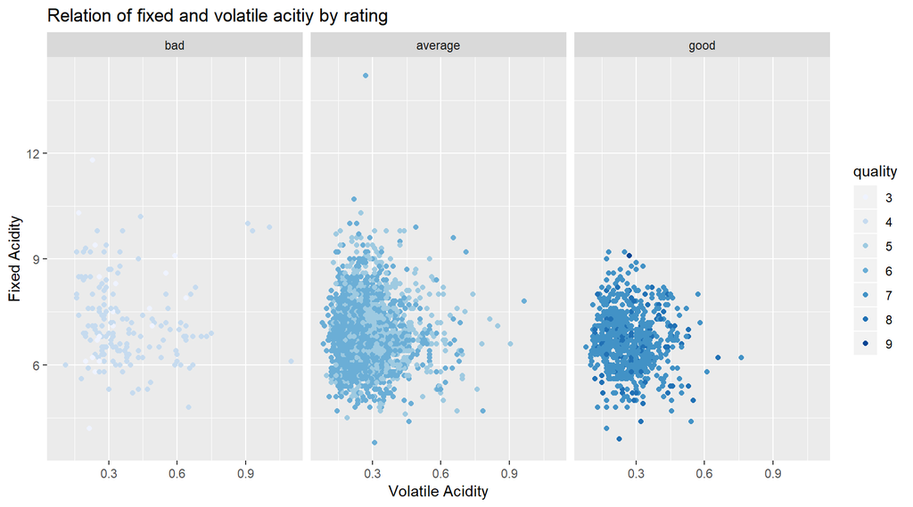

Taking a look at the relation between fixed and volatile acidity in terms of quality, we can see that good rated wines seem to come with a lower fixed and volatile acidity.

### Linear models for comparison of variables

```
##
## Calls:
## Model_1: lm(formula = as.numeric(quality) ~ alcohol, data = training_data)
## Model_2: lm(formula = as.numeric(quality) ~ alcohol + residual.sugar,
##     data = training_data)
## Model_3: lm(formula = as.numeric(quality) ~ alcohol + residual.sugar +
##     fixed.acidity, data = training_data)
## Model_4: lm(formula = as.numeric(quality) ~ alcohol + residual.sugar +
##     fixed.acidity + volatile.acidity, data = training_data)
## Model_5: lm(formula = as.numeric(quality) ~ alcohol + residual.sugar +
##     fixed.acidity + volatile.acidity + citric.acid, data = training_data)
## Model_6: lm(formula = as.numeric(quality) ~ alcohol + residual.sugar +
##     fixed.acidity + volatile.acidity + citric.acid + sulphates,
##     data = training_data)
## Model_7: lm(formula = as.numeric(quality) ~ alcohol + residual.sugar +
##     pH, data = training_data)
##
## ======================================================================================================================
##                       Model_1       Model_2       Model_3       Model_4       Model_5       Model_6       Model_7
## ----------------------------------------------------------------------------------------------------------------------
##   (Intercept)           0.584***      0.083         0.492*        0.773***      0.768***      0.541**      -0.872*
##                        (0.128)       (0.151)       (0.202)       (0.196)       (0.196)       (0.207)       (0.352)
##   alcohol               0.314***      0.350***      0.346***      0.369***      0.369***      0.371***      0.349***
##                        (0.012)       (0.013)       (0.013)       (0.013)       (0.013)       (0.013)       (0.013)
##   residual.sugar                      0.020***      0.020***      0.026***      0.026***      0.026***      0.021***
##                                      (0.003)       (0.003)       (0.003)       (0.003)       (0.003)       (0.003)
##   fixed.acidity                                    -0.055**      -0.054**      -0.056**      -0.054**
##                                                    (0.018)       (0.017)       (0.018)       (0.018)
##   volatile.acidity                                               -2.038***     -2.029***     -2.025***
##                                                                  (0.138)       (0.139)       (0.139)
##   citric.acid                                                                   0.050         0.027
##                                                                                (0.121)       (0.121)
##   sulphates                                                                                   0.418***
##                                                                                              (0.125)
##   pH                                                                                                        0.300**
##                                                                                                            (0.100)
## ----------------------------------------------------------------------------------------------------------------------
##   R-squared             0.188         0.198         0.201         0.256         0.256         0.259         0.201
##   adj. R-squared        0.188         0.198         0.200         0.255         0.255         0.258         0.200
##   sigma                 0.804         0.799         0.798         0.770         0.770         0.769         0.798
##   F                   679.385       362.568       245.524       252.760       202.184       170.929       245.373
##   p                     0.000         0.000         0.000         0.000         0.000         0.000         0.000
##   Log-likelihood    -3528.472     -3509.899     -3505.215     -3399.148     -3399.063     -3393.484     -3505.397
##   Deviance           1899.005      1875.155      1869.188      1739.025      1738.925      1732.335      1869.419
##   AIC                7062.944      7027.798      7020.431      6810.295      6812.127      6802.968      7020.794
##   BIC                7080.901      7051.741      7050.360      6846.210      6854.028      6850.855      7050.723
##   N                  2939          2939          2939          2939          2939          2939          2939
## ======================================================================================================================
```

# Multivariate Analysis

### Talk about some of the relationships you observed in this part of the investigation. Were there features that strengthened each other in terms of looking at your feature(s) of interest?

One of the most obvious relationships is alcohol, residual sugar and quality. You could also say they strenghened each other in a negative way, meaning we have a negative correlation here. The more residual sugar a wine as, the less alcohol it has and with alcohol going down, the quality seems to go down as well.

Same goes for density. If we have a higher density, the alcohol value goes down and so does the quality.

Citric acid and fixed acidity seem to strengthen each other as well (negatively), as good wines seem to have less citrix acid and fixed acidity than average wines.

### Were there any interesting or surprising interactions between features?

Not really, as most of the interactions were kind of obvious because of the bivariate plotting we did before. Most of the time, the multivariate plots confirmed what we started to see in the bivariate section.

### OPTIONAL: Did you create any models with your dataset? Discuss the strengths and limitations of your model.

Yes, i did create models in order to see to which degree the variables are able to explain the variability in the data. But in our model, the r square values are quite low, so that it is difficult to take the variables alone to predict quality of wine. This might be due to the somewhat high number of average rated wines in our dataset.

I think besides the chemical and physical properties which are in our dataset, there might be other factors which have a influence on the quality of wine, such as the taste, which maybe can’t be explained by this value alone. Furthermore, i suppose that personal opinions might have an big influence on the rating of a wine.

# Final Plots and Summary

### Plot One

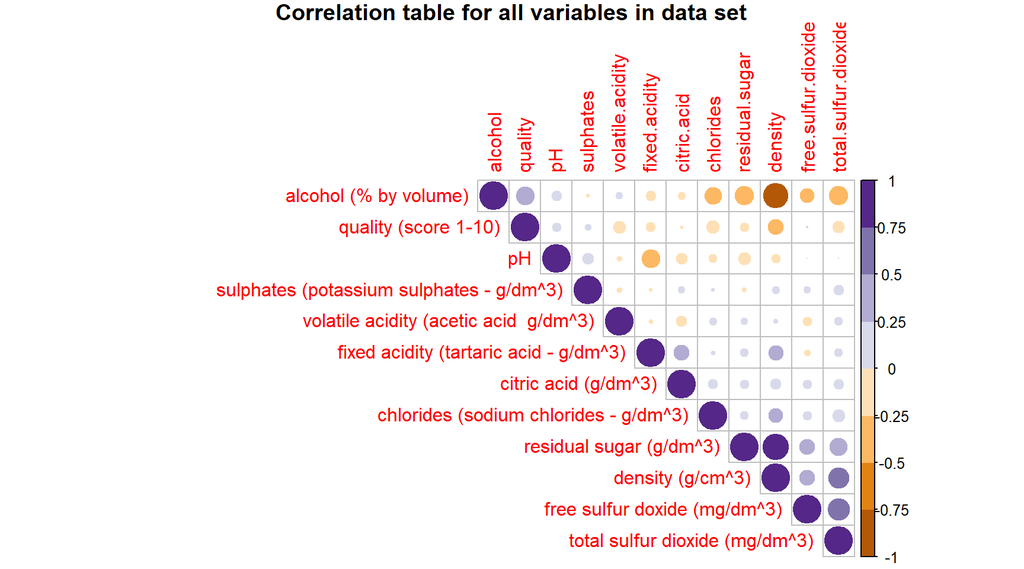

### Description One

I chose this plot, as the correlation table gives a good overview of which variables are correlating in which way. From there on, i started my bivariate and multivariate analysis. If you plot an overview like this first, you know where it is worth it to investigate further and dive deeper.

### Plot Two

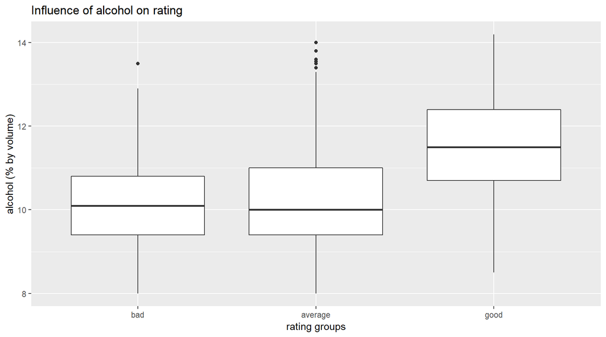

### Description Two

This plot shows the distribution of alcohol for bad, average and good rated wines. Honestly, i wasn’t aware of this correlation before i got to plot it. Good wines seem to have a higher percentage of alcohol.

### Plot Three

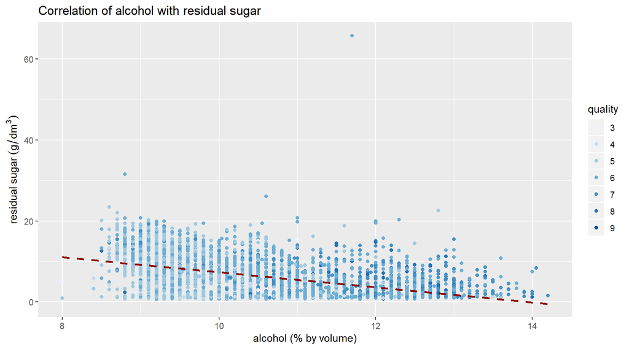

### Description Three

This plot is closely related to the plot before. If we take a look at the correlation matrix, there doesn’t seem to be a correlation between quality and residual sugar. But if we pot it into a multivariate plot, we can see there is in fact one. It is not a direct correlation, but as the quality positively correlates with alcohol and alcohol itself correlates negatively with residual sugar, we indeed have a correlation between residual sugar and quality.

# Reflection

We have a dataset with white wines and their chemical properties right here. After getting a feeling for the data by doing univariate analysis, i started to investigate relations with bivariate and multivariate analysis.

As our main questions is: “Which properties are influencing the quality of a whine and make up for a good or bad?” i started to take a look at the distribution of the quality ratings. Therefore, i grouped the quality values into a rating value, which made me able to see that we had quite lot average whine, but less bad or good wines.

Taking a look at the properties and their summaries right at the beginning, i discovered that there are wines which do not contain citric acid. At first, i thought that might be due to bad data, but then i read on https://en.wikipedia.org/wiki/Acids_in_wine that it is not allowed to acid citric acid for aciditation in the European union. Adding citric acid is only allowed in order to remove iron and cooper. I think that this is way there may be wines that have no citric acid.

Most variables are slightly skewed to the right, with some being almost normal distributed. Residual sugar is in fact one variable with is “heavily” skewed to the right.

In order to get a clue which properties are related to each other and make up for a good quality or rating, i did a correlation matrix, to get a quick overview. This helped me to get a feeling on how to start and what to do next. Before plotting this matrix, i was about to plot single plots one after the other, but this way i already knew what to do next and what to expect from my new plots. This helped me alot. Especially when it comes to the relation of residual sugar and alcohol and alcohol to quality.

When taking a look at linear models i discovered, that e. g. alcohol only explained about 18% of the variability. Same goes for the later model. This led me to the conclusion that there might be other variables which are not in our dataset and maybe might not be measurable, such as every person might taste differently and judge / rate on his preferences.

For future studies, i would like to have a look at the geographical source of those wines, as well as the age of wines, which might have a kind o “psychological” influence on the rating.